# ERP model

## WORDCAT DEVELOP

```r
write("dev wordcat", stderr())
cat.df = subset(develop.df,str_detect(Condition,"(CATCONT|CATVIOL)") & ! measure %in% c("error", "myoutputder","myinputder","outderiv"))

cat.df$Condition=factor(cat.df$Condition,labels=c("Control","Violation"))
verbpos = which(cat.df$wordcat == "VERBI")
wordcatsamelen = which(cat.df$wordcat!=cat.df$wordcat[1])[1]-1
verb.df = cat.df[verbpos,] #  verb
postverb.df = cat.df[verbpos + wordcatsamelen,] # position after verb
postverb.df=postverb.df[!is.na(postverb.df$Condition),]
postverb.df=postverb.df[!is.na(postverb.df$Condition),]

print(head(postverb.df[postverb.df$measure=="target",c("word","wordcat","Condition","Example","tick","epoch")])) # check
```

```
##       word wordcat Condition                                    Example
## 31942   -s      PL   Control   the grandma was take -ing the nap -s . .
## 32072  -ed      ED Violation  the grandma was take -ing the nap -ed . .
## 65989   -s      PL   Control           the girl take -ed the nap -s . .
## 66106  -ed      ED Violation          the girl take -ed the nap -ed . .
## 79067   -s      PL   Control     a teacher was take -ing the nap -s . .
## 79197  -ed      ED Violation    a teacher was take -ing the nap -ed . .
##       tick epoch
## 31942    8 10000
## 32072    8 10000
## 65989    7 10000
## 66106    7 10000
## 79067    8 10000
## 79197    8 10000
```

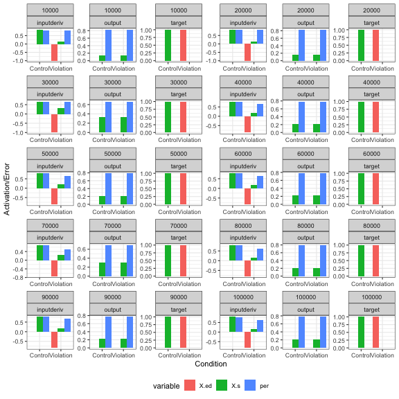

```r
postverb2.df = subset(postverb.df, layer == "word")
postverb2.df$X.s=abs(postverb2.df$X.s)
postverb2.df$X.ss=abs(postverb2.df$X.ss)
postverb2.df$per=abs(postverb2.df$per)
p1=showWordOutError("X.ed,X.s,per",c("Condition","epoch","measure"),postverb2.df)
p1=p1+theme_bw()+ylab("Activation/Error")
#p1 =p1 + scale_fill_discrete(name="Word Unit",labels=c("3rdSingular", "Plural", "End of sentence"))
p1 = p1+ theme(legend.position="bottom")
p1
```

```r
#myggsave("img/devoutput.png",width=figwidth,height=figheight)
```

```r
corrHiddenOutputInputDeriv(postverb.df,"Condition","epoch")
```

```
## Condition
##   Control Violation
##         8         8
```

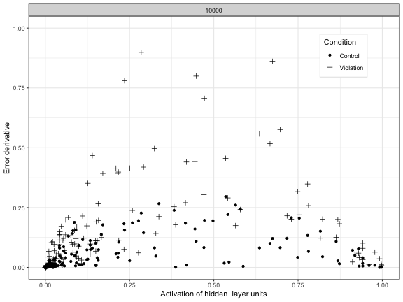

```r
epochnum = which(names(postverb.df)=="epoch")
postverb2.df = postverb.df[,c(epochnum,1:epochnum-1,(epochnum+1):length(postverb.df))]
mapping = aes(x=depth, y=value, colour = Condition,linetype=Condition)
norawpostverbnotargout.df=removeWordsDrawERP(postverb.df,"value", "Condition", "epoch")
```

```
##   sub epoch word wordcat contfunc
## 1  s0 10000   -s      PL        F
## 2  s0 10000   -s      PL        F
## 3  s0 10000   -s      PL        F
## 4  s0 10000  -ed      ED        F
## 5  s0 10000  -ed      ED        F
## 6  s0 10000  -ed      ED        F
##                                      Example Condition tick    layer
## 1   the grandma was take -ing the nap -s . .   Control    8     word
## 2   the grandma was take -ing the nap -s . .   Control    8 compress
## 3   the grandma was take -ing the nap -s . .   Control    8   hidden
## 4  the grandma was take -ing the nap -ed . . Violation    8     word
## 5  the grandma was take -ing the nap -ed . . Violation    8 compress
## 6  the grandma was take -ing the nap -ed . . Violation    8   hidden
##      measure depth variable    value
## 1 inputderiv     1   abssum 1.813802
## 2 inputderiv     2   abssum 1.961948
## 3 inputderiv     3   abssum 2.436346
## 4 inputderiv     1   abssum 1.999954
## 5 inputderiv     2   abssum 3.906386
## 6 inputderiv     3   abssum 7.498786
```

```r
interactionText="NO TEXT"
modellist2 = list()

childtime = 30000
certainepochs.df = subset(norawpostverbnotargout.df, epoch %in% c(childtime,100000))
#certainepochs.df = norawpostverbnotargout.df

# get example for table
catwordexample = subset(certainepochs.df,measure == mainMeasure  & layer == "word")
exampleTable = catwordexample[1:4,c("Condition","Example")]
tabletext = kable(exampleTable,format="latex",row.names=FALSE)
print(exampleTable)
```

```
##        Condition                                    Example
## 118342   Control   the grandma was take -ing the nap -s . .
## 118472 Violation  the grandma was take -ing the nap -ed . .
## 152389   Control           the girl take -ed the nap -s . .
## 152506 Violation          the girl take -ed the nap -ed . .
```

```r
catinput  = subset(certainepochs.df,measure == mainMeasure & layer %in% c("word",p600layer) )

if (nlevels(adultdata.df$sub) > 4){ # do mixed with more than 9 subj

  catinput$cviolation = ifelse(catinput$Condition=="Violation",0.5,-0.5) # one against two
  catinput$cword = ifelse(catinput$layer=="word",0.5,-0.5)
  catinput$cepoch = scale(catinput$epoch)
  catinput$sub = factor(catinput$sub)
  # this is the main mixed model with centered variables
  randomeff = paste(" + (1 + Condition |sub)")   # Condition * epoch
  if (noslopes){ randomeff = " + (1 | sub)"}
  formu = as.formula(paste(dependMeasure,"~ cviolation*cepoch*cword",randomeff))
  omnimodel = lmer(formu, catinput,control=lmerControl(optimizer = "bobyqa",optCtrl=list(maxfun=50000)))
  print(summary(omnimodel))
#  modellist2 = modelComparison(omnimodel) # create anova table

  catinputword = subset(catinput,layer == "word")
  catinputword$cviolation = ifelse(catinputword$Condition=="Violation",0.5,-0.5) # one against two
  catinputword$cword = ifelse(catinputword$layer=="word",0.5,-0.5)
  catinputword$cepoch = scale(catinputword$epoch)
  catinputword$sub = factor(catinputword$sub)
  # this is the main mixed model with centered variables
  randomeff = paste(" + (1 + Condition  |sub)")   # Condition * epoch
  if (noslopes){ randomeff = " + (1 | sub)"}
  formu = as.formula(paste(dependMeasure,"~ cviolation*cepoch",randomeff))
  omnimodel = lmer(formu, catinputword,control=lmerControl(optimizer = "bobyqa",optCtrl=list(maxfun=50000)))
  print(summary(omnimodel))

  modellist2 = modelComparison(omnimodel) # create anova table

  # this model is for posthocs
  catinputword$depoch = factor(catinputword$epoch)
  formu2 = as.formula(paste(dependMeasure,"~ Condition*depoch",randomeff))
  omnimodelFactor = lmer(formu2, catinputword)
  print(summary(omnimodelFactor))
  model.lsmobj <- lsmeans(omnimodelFactor, ~ Condition | depoch)
  posthocs = summary(as.glht(pairs(model.lsmobj)))
  print(posthocs)
  interactionText = printInteraction(posthocs)

}
```

```
## Linear mixed model fit by REML ['lmerMod']
## Formula: abssum ~ cviolation * cepoch * cword + (1 + Condition | sub)
##    Data: catinput
## Control: lmerControl(optimizer = "bobyqa", optCtrl = list(maxfun = 50000))
##
## REML criterion at convergence: 7582.1
##
## Scaled residuals:
##     Min      1Q  Median      3Q     Max
## -3.3427 -0.5346 -0.0764  0.4336  5.6361
##
## Random effects:
##  Groups   Name               Variance Std.Dev. Corr
##  sub      (Intercept)        0.1789   0.4229
##           ConditionViolation 0.5741   0.7577   -0.03
##  Residual                    1.3295   1.1530
## Number of obs: 2400, groups:  sub, 10
##
## Fixed effects:
##                         Estimate Std. Error t value
## (Intercept)              2.22154    0.17806  12.477
## cviolation               1.55626    0.24419   6.373
## cepoch                  -0.15265    0.02354  -6.484
## cword                   -1.15875    0.04707 -24.616
## cviolation:cepoch       -0.32290    0.04708  -6.858
## cviolation:cword        -2.39400    0.09415 -25.429
## cepoch:cword             0.25189    0.04708   5.350
## cviolation:cepoch:cword  0.05251    0.09417   0.558
##
## Correlation of Fixed Effects:
##             (Intr) cviltn cepoch cword cvltn:cp cvltn:cw cpch:c
## cviolation  0.635
## cepoch      0.000  0.000
## cword       0.000  0.000  0.000
## cviltn:cpch 0.000  0.000  0.000  0.000
## cviltn:cwrd 0.000  0.000  0.000  0.000 0.000
## cepoch:cwrd 0.000  0.000  0.000  0.000 0.000    0.000
## cvltn:cpch: 0.000  0.000  0.000  0.000 0.000    0.000    0.000
## Linear mixed model fit by REML ['lmerMod']
## Formula: abssum ~ cviolation * cepoch + (1 + Condition | sub)
```

[output cut: 14 more lines]

```
## Number of obs: 1200, groups:  sub, 10
##
## Fixed effects:
##                    Estimate Std. Error t value
## (Intercept)        1.642167   0.077183  21.276
## cviolation         0.359260   0.097011   3.703
## cepoch            -0.026705   0.009317  -2.866
## cviolation:cepoch -0.296705   0.018634 -15.923
##
## Correlation of Fixed Effects:
##             (Intr) cviltn cepoch
## cviolation  0.429
## cepoch      0.000  0.000
## cviltn:cpch 0.000  0.000  0.000
## [1] "remove . ~ . -  cviolation:cepoch "
```

```
## refitting model(s) with ML (instead of REML)
```

```
## Data: catinputword
## Models:
## model2: abssum ~ cviolation + cepoch + (1 + Condition | sub)
## model: abssum ~ cviolation * cepoch + (1 + Condition | sub)
##        Df    AIC     BIC  logLik deviance  Chisq Chi Df Pr(>Chisq)
## model2  7 1003.5 1039.15 -494.76   989.52
## model   8  775.5  816.22 -379.75   759.50 230.02      1  < 2.2e-16 ***
## ---
## Signif. codes:  0 '***' 0.001 '**' 0.01 '*' 0.05 '.' 0.1 ' ' 1
## [1] "########## Above comparison for  cviolation:cepoch  *** "
## [1] "remove . ~ . -  cepoch "
```

```
## refitting model(s) with ML (instead of REML)
```

```
## Data: catinputword
## Models:
## model2: abssum ~ cviolation + (1 + Condition | sub)
## model: abssum ~ cviolation + cepoch + (1 + Condition | sub)
##        Df    AIC    BIC  logLik deviance  Chisq Chi Df Pr(>Chisq)
## model2  6 1008.3 1038.8 -498.14   996.27
## model   7 1003.5 1039.2 -494.76   989.52 6.7525      1   0.009361 **
## ---
## Signif. codes:  0 '***' 0.001 '**' 0.01 '*' 0.05 '.' 0.1 ' ' 1
## [1] "########## Above comparison for  cepoch  *** "
## [1] "remove . ~ . -  cviolation "
```

```
## refitting model(s) with ML (instead of REML)
```

```
## Data: catinputword
## Models:
## model2: abssum ~ (1 + Condition | sub)
## model: abssum ~ cviolation + (1 + Condition | sub)
##        Df    AIC    BIC  logLik deviance  Chisq Chi Df Pr(>Chisq)
## model2  5 1015.5 1041.0 -502.76  1005.53
## model   6 1008.3 1038.8 -498.14   996.27 9.2577      1   0.002345 **
## ---
## Signif. codes:  0 '***' 0.001 '**' 0.01 '*' 0.05 '.' 0.1 ' ' 1
## [1] "########## Above comparison for  cviolation  *** "
## Linear mixed model fit by REML ['lmerMod']
## Formula: abssum ~ Condition * depoch + (1 + Condition | sub)
##    Data: catinputword
##
## REML criterion at convergence: 776.8
##
## Scaled residuals:
##     Min      1Q  Median      3Q     Max
## -4.0293 -0.5367  0.0738  0.5620  2.7875
##
## Random effects:
##  Groups   Name               Variance Std.Dev. Corr
##  sub      (Intercept)        0.04928  0.2220
##           ConditionViolation 0.09064  0.3011   -0.20
##  Residual                    0.10408  0.3226
## Number of obs: 1200, groups:  sub, 10
##
## Fixed effects:
##                                 Estimate Std. Error t value
## (Intercept)                      1.34094    0.07263  18.464
## ConditionViolation               0.65584    0.09878   6.639
## depoch100000                     0.24319    0.02634   9.232
## ConditionViolation:depoch100000 -0.59316    0.03725 -15.923
##
## Correlation of Fixed Effects:
##             (Intr) CndtnV d10000
## ConditnVltn -0.233
## depch100000 -0.181  0.133
## CndV:100000  0.128 -0.189 -0.707
```

```
## Note: df set to 9
```

```
## $`depoch = 30000`
##
##   Simultaneous Tests for General Linear Hypotheses
##
## Linear Hypotheses:
##                          Estimate Std. Error t value Pr(>|t|)
## Control - Violation == 0 -0.65584    0.09878  -6.639 9.49e-05 ***
## ---
## Signif. codes:  0 '***' 0.001 '**' 0.01 '*' 0.05 '.' 0.1 ' ' 1
## (Adjusted p values reported -- single-step method)
##
##
## $`depoch = 100000`
##
##   Simultaneous Tests for General Linear Hypotheses
##
## Linear Hypotheses:
##                          Estimate Std. Error t value Pr(>|t|)
## Control - Violation == 0 -0.06268    0.09878  -0.634    0.542
## (Adjusted p values reported -- single-step method)
```

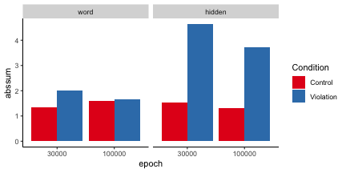

```r
form = as.formula(paste(dependMeasure," ~ Condition + epoch + layer",sep=""))
meandf = aggregate(form, catinput, mean)
mapping = aes_string(x="epoch", y=dependMeasure, fill = "Condition")
meandf$epoch= factor(meandf$epoch)
p=ggplot(meandf, mapping)
p=p+geom_bar(position="dodge",stat="identity")
p = p + scale_fill_brewer(palette = "Set1")
p=p+facet_wrap(~ layer)
p=p + theme(panel.grid.major = element_blank(),
                  panel.grid.minor = element_blank(),
                  panel.background = element_blank(),
                  axis.line = element_line(colour = "black"))
p
```

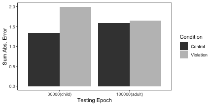

```r
catinputword = subset(catinput, layer == "word")

form = as.formula(paste(dependMeasure," ~ Condition + epoch ",sep=""))
meandf = aggregate(form, catinputword, mean)
mapping = aes_string(x="epoch", y=dependMeasure, fill = "Condition")
meandf$epoch= factor(meandf$epoch,labels = c(paste(childtime,"(child)",sep=""),"100000(adult)"))
p=ggplot(meandf, mapping)
p=p+geom_bar(position="dodge",stat="identity")+theme_bw()
#p = p + scale_fill_brewer(palette = "Set1")
p = p + scale_fill_grey(start = 0.25, end = 0.75)
p = p +ylab("Sum Abs. Error")+xlab("Testing Epoch")
p=p + theme(panel.grid.major = element_blank(),
                  panel.grid.minor = element_blank(),
                  panel.background = element_blank(),
                  axis.line = element_line(colour = "black"))
p
```

```r
  if (!noslopes){ # when doing final version, change noslopes to FALSE??n
    myggsave("img/catdevelop.png",width=figwidth,height=figheight)
  }
```

CUT AND PASTE INTO LATEX DOC click in box and use right arrow to see whole text

```latex
This is an example of the stimuli used in the model.


\begin{tabular}{l|l}
\hline
Condition & Example\\
\hline
Control & the grandma was take -ing the nap -s . .\\
\hline
Violation & the grandma was take -ing the nap -ed . .\\
\hline
Control & the girl take -ed the nap -s . .\\
\hline
Violation & the girl take -ed the nap -ed . .\\
\hline
\end{tabular}
The maximal model for the data had random slopes  + (1 + Condition  |sub)

Mixed Model Results
a main effect of cviolation ,$\beta$=0.36, SE=0.097, $\chi^2$(1)=9.26, p=0.0023
a main effect of cepoch ,$\beta$=-0.027, SE=0.0093, $\chi^2$(1)=6.75, p=0.0094
@@an interaction of cviolation:cepoch ,$\beta$=-0.3, SE=0.019, $\chi^2$(1)=230.02, p$<$0.001

Posthoc tests for  depoch = 30000
 @@Posthoc: There was a significant difference for Control - Violation, diff = 0.6558, t(9)=6.64, p$<$0.001
Posthoc tests for  depoch = 100000
 @@Posthoc: There was no difference for Control - Violation, p=0.5415
ratio  Control - Violation   0.096  rev  10.459
```

## Coulson et al

```r
# This is Coulson et al
write("Coulson et al", stderr())
coulagree.df = subset(couldf,  str_detect(Condition,"(SING|PLUR)") )
verbpos = which(coulagree.df$wordcat == "VERBT")
wordcatsamelen = which(coulagree.df$wordcat!=coulagree.df$wordcat[1])[1]-1
verb.df = coulagree.df[verbpos,] #  verb
postverbcoul.df = coulagree.df[verbpos + wordcatsamelen,] # position after verb
postverbcoul.df=postverbcoul.df[!is.na(postverbcoul.df$Condition),]

postverbcoul.df = cbind(Probability="",Number="",Agreement="",postverbcoul.df)
cond = str_split_fixed(postverbcoul.df$Condition,";",2)
postverbcoul.df$Number = cond[,1]
postverbcoul.df$Agreement = cond[,2]
postverbcoul.df$Number = factor(postverbcoul.df$Number,labels=c("Singular"))
postverbcoul.df$Agreement = factor(postverbcoul.df$Agreement,labels=c("Control","Violation"))
postverbcoul.df$Probability=NA
postverbcoul.df$Probability[postverbcoul.df$Agreement=="Violation" & str_detect(postverbcoul.df$coul,"vcoul1")] = "Improbable"
postverbcoul.df$Probability[postverbcoul.df$Agreement=="Violation" & str_detect(postverbcoul.df$coul,"vcoul2")] = "Probable"
postverbcoul.df$Probability[postverbcoul.df$Agreement=="Control" & str_detect(postverbcoul.df$coul,"vcoul2")] = "Improbable"
postverbcoul.df$Probability[postverbcoul.df$Agreement=="Control" & str_detect(postverbcoul.df$coul,"vcoul1")] = "Probable"
postverbcoul.df$Probability=factor(postverbcoul.df$Probability)

xtabs(~ Agreement +Probability,postverbcoul.df)
```

```
##            Probability
## Agreement   Improbable Probable
##   Control          600     2400
##   Violation        600     2400
```

```r
print(head(postverbcoul.df[postverbcoul.df$measure=="target",c("word","wordcat","Condition","Example","tick")])) # check
```

```
##      word wordcat Condition                               Example tick
## 157   -ss      SS SING;CONT          the boy take -ss a stick . .    4
## 391  wine   NOUNI PLUR;CONT       the father -s taste wine -s . .    5
## 612     a     DET SING;VIOL            the mother push a kite . .    4
## 846   the     DET PLUR;CONT          the wife -s take the toy . .    5
## 1054  -ss      SS SING;CONT  the brother taste -ss the tea -s . .    4
## 1301  the     DET PLUR;CONT        the clerk -s drink the tea . .    5
```

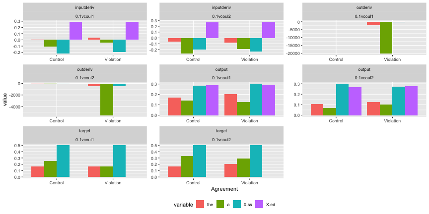

```r
showWordOutError("the,a,X.ss,X.ed",c("Agreement","measure","coul"),postverbcoul.df)
```

```r
corrHiddenOutputInputDeriv(postverbcoul.df,"Probability", "Agreement")
```

```
## Condition
##               ACTCONT               CATCONT               CATVIOL
##                     0                     0                     0
##                  CONG               GARDAMB                GARDSC
##                     0                     0                     0
##             HIGHCLOZE                 INCOH              LOWCLOZE
##                     0                     0                     0
##              PASSCONT             PLUR;CONT             PLUR;VIOL
##                     0                    14                     2
##               SEMATTR             SING;CONT             SING;VIOL
##                     0                    12                     4
##               STRONG    STRONGCONS;EXPECTED STRONGCONS;UNEXPECTED
##                     0                     0                     0
##               SUBCONT               SUBVIOL             TENSECONT
##                     0                     0                     0
##             TENSEVIOL             TEST-PRED           TEST-UNPRED
##                     0                     0                     0
##                  WEAK                 WEAK      WEAKCONS;EXPECTED
##                     0                     0                     0
##   WEAKCONS;UNEXPECTED             ́ZEROCLOZE
##                     0                     0
```

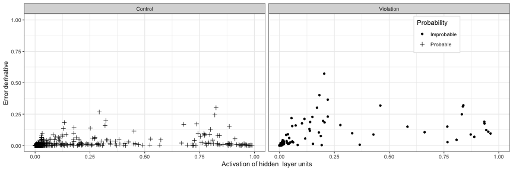

```r
# make erp figure with different measures
#mapping = aes(x=depth, y=value, colour = Agreement,linetype=Probability)
coulnorawpostverbnotargout.df=removeWordsDrawERP(postverbcoul.df,"value","Probability","Agreement")
```

```
##   Probability    Number Agreement sub      coul devellearn  epoch word
## 1    Probable Singular2   Control  s0 0.1vcoul1       <NA> 100000  -ss
## 2    Probable Singular2   Control  s0 0.1vcoul1       <NA> 100000  -ss
## 3    Probable Singular2   Control  s0 0.1vcoul1       <NA> 100000  -ss
## 4    Probable Singular2   Control  s0 0.1vcoul1       <NA> 100000  -ss
## 5    Probable Singular2   Control  s0 0.1vcoul1       <NA> 100000  -ss
## 6    Probable Singular2   Control  s0 0.1vcoul1       <NA> 100000  -ss
##   wordcat contfunc                       Example Condition tick    layer
## 1      SS        F  the boy take -ss a stick . . SING;CONT    4     word
## 2      SS        F  the boy take -ss a stick . . SING;CONT    4     word
## 3      SS        F  the boy take -ss a stick . . SING;CONT    4 compress
## 4      SS        F  the boy take -ss a stick . . SING;CONT    4 compress
## 5      SS        F  the boy take -ss a stick . . SING;CONT    4   hidden
## 6      SS        F  the boy take -ss a stick . . SING;CONT    4   hidden
##      measure depth variable      value
## 1   outderiv     1   abssum  2.4385430
## 2 inputderiv     1   abssum  1.1798382
## 3   outderiv     2   abssum 26.3264316
## 4 inputderiv     2   abssum  0.1031967
## 5   outderiv     3   abssum  2.8054352
## 6 inputderiv     3   abssum  0.1231286
```

```r
interactionText="NO TEXT"
modellist2 = list()

# get example for table
agreeinputword = subset(coulnorawpostverbnotargout.df,measure == mainMeasure  & layer == "word")
exampleTable = agreeinputword[1:4,c("Number","Agreement","Example")]
tabletext = kable(exampleTable,format="latex",row.names=FALSE)
print(exampleTable)
```

```
##        Number Agreement                          Example
## 159 Singular2   Control     the boy take -ss a stick . .
## 393 Singular1   Control  the father -s taste wine -s . .
## 614 Singular2 Violation       the mother push a kite . .
## 848 Singular1   Control     the wife -s take the toy . .
```

```r
coulagreeinput  = subset(coulnorawpostverbnotargout.df,measure == mainMeasure & layer %in% c("word",p600layer) )

if (nlevels(adultdata.df$sub) > 4){ # do mixed with more than 9 subj

  coulagreeinput$cplural = ifelse(coulagreeinput$Number=="Plural",0.5,-0.5)
  coulagreeinput$cviolation = ifelse(coulagreeinput$Agreement=="Violation",0.5,-0.5)
  coulagreeinput$cp6layer = ifelse(coulagreeinput$layer==p600layer,0.5,-0.5)
  coulagreeinput$cprob = ifelse(coulagreeinput$Probability=="Probable",0.5,-0.5)

  #- cviolation:cp6layer:cprob  -cviolation:cp6layer - cviolation:cprob - cp6layer:cprob - cp6layer
  # this is the main mixed model with centered variables
  #cviolation*cp6layer*cprob -cviolation:cp6layer:cprob -cviolation:cp6layer -cviolation:cprob - cp6layer:cprob - cp6layer -cviolation -cprob
    randomeff = paste(" + (1 + cviolation*cp6layer*cprob - cviolation:cp6layer:cprob |sub)")  #cviolation*cp6layer*cprob
      if (noslopes){ randomeff = " + (1 | sub)"}
  formu = as.formula(paste(dependMeasure,"~ cviolation*cp6layer*cprob",randomeff))
  omnimodel = lmer(formu, coulagreeinput,control=lmerControl(optimizer = "bobyqa",optCtrl=list(maxfun=50000)))
  print(summary(omnimodel))

  modellist2 = modelComparison(omnimodel) # create anova table
  # this model is for posthocs
  formu2 = as.formula(paste(dependMeasure,"~ Probability*layer",randomeff))
  omnimodelFactor = lmer(formu2, coulagreeinput)
#  print(summary(omnimodelFactor))
  model.lsmobj <- lsmeans(omnimodelFactor, ~ Probability | layer)
  posthocs = summary(as.glht(pairs(model.lsmobj)))
  print(posthocs)
  interactionText = printInteraction(posthocs)

}
```

```
## Linear mixed model fit by REML ['lmerMod']
## Formula:
## abssum ~ cviolation * cp6layer * cprob + (1 + cviolation * cp6layer *
##     cprob - cviolation:cp6layer:cprob | sub)
##    Data: coulagreeinput
## Control: lmerControl(optimizer = "bobyqa", optCtrl = list(maxfun = 50000))
##
## REML criterion at convergence: 4161.8
##
## Scaled residuals:
##     Min      1Q  Median      3Q     Max
## -2.6801 -0.4342 -0.0431  0.1782  7.1270
##
## Random effects:
##  Groups   Name                Variance Std.Dev. Corr
##  sub      (Intercept)         0.04227  0.2056
##           cviolation          0.02921  0.1709   -0.77
##           cp6layer            0.11735  0.3426    1.00 -0.74
##           cprob               0.08865  0.2977   -0.84  0.80 -0.84
##           cviolation:cp6layer 0.06507  0.2551   -0.12  0.73 -0.08  0.38
##           cviolation:cprob    0.17542  0.4188    0.59 -0.28  0.57 -0.06
##           cp6layer:cprob      0.28769  0.5364   -0.89  0.81 -0.89  1.00
##  Residual                     1.82580  1.3512
##
##
##
##
##
##
##   0.26
##   0.35 -0.15
##
## Number of obs: 1200, groups:  sub, 10
##
## Fixed effects:
##                           Estimate Std. Error t value
## (Intercept)                2.02474    0.08127  24.914
## cviolation                 0.97278    0.11149   8.725
## cp6layer                   0.80395    0.14576   5.516
## cprob                     -0.84013    0.13555  -6.198
## cviolation:cp6layer        0.84837    0.21105   4.020
## cviolation:cprob           0.19242    0.23575   0.816
## cp6layer:cprob            -1.19948    0.25847  -4.641
## cviolation:cp6layer:cprob  0.14818    0.39006   0.380
##
## Correlation of Fixed Effects:
##             (Intr) cviltn cp6lyr cprob  cvlt:6 cvltn: cp6ly:
## cviolation  -0.298
## cp6layer     0.594 -0.267
## cprob       -0.725  0.268 -0.436
## cvltn:cp6ly -0.038  0.135 -0.024  0.101
## cviltn:cprb  0.265 -0.511  0.239 -0.022  0.056
## cp6lyr:cprb -0.465  0.259 -0.737  0.454  0.088 -0.055
## cvltn:cp6l:  0.000  0.000  0.000  0.000 -0.554  0.000  0.000
## [1] "remove . ~ . -  cviolation:cp6layer:cprob "
```

```
## refitting model(s) with ML (instead of REML)
```

```
## Data: coulagreeinput
## Models:
## model2: abssum ~ cviolation + cp6layer + cprob + (1 + cviolation * cp6layer *
## model2:     cprob - cviolation:cp6layer:cprob | sub) + cviolation:cp6layer +
## model2:     cviolation:cprob + cp6layer:cprob
## model: abssum ~ cviolation * cp6layer * cprob + (1 + cviolation * cp6layer *
## model:     cprob - cviolation:cp6layer:cprob | sub)
##        Df    AIC    BIC  logLik deviance Chisq Chi Df Pr(>Chisq)
## model2 36 4218.0 4401.2 -2073.0   4146.0
## model  37 4219.5 4407.8 -2072.7   4145.5 0.519      1     0.4713
## [1] "########## Above comparison for  cviolation:cp6layer:cprob "
## [1] "remove . ~ . -  cp6layer:cprob "
```

```
## refitting model(s) with ML (instead of REML)
```

```
## Data: coulagreeinput
## Models:
## model2: abssum ~ cviolation + cp6layer + cprob + (1 + cviolation * cp6layer *
## model2:     cprob - cviolation:cp6layer:cprob | sub) + cviolation:cp6layer +
## model2:     cviolation:cprob
## model: abssum ~ cviolation + cp6layer + cprob + (1 + cviolation * cp6layer *
## model:     cprob - cviolation:cp6layer:cprob | sub) + cviolation:cp6layer +
## model:     cviolation:cprob + cp6layer:cprob
##        Df    AIC    BIC  logLik deviance  Chisq Chi Df Pr(>Chisq)
## model2 35 4228.3 4406.4 -2079.1   4158.3
## model  36 4218.0 4401.2 -2073.0   4146.0 12.286      1  0.0004564 ***
## ---
## Signif. codes:  0 '***' 0.001 '**' 0.01 '*' 0.05 '.' 0.1 ' ' 1
## [1] "########## Above comparison for  cp6layer:cprob  *** "
## [1] "remove . ~ . -  cviolation:cprob "
```

```
## refitting model(s) with ML (instead of REML)
```

```
## Data: coulagreeinput
## Models:
## model2: abssum ~ cviolation + cp6layer + cprob + (1 + cviolation * cp6layer *
## model2:     cprob - cviolation:cp6layer:cprob | sub) + cviolation:cp6layer
## model: abssum ~ cviolation + cp6layer + cprob + (1 + cviolation * cp6layer *
## model:     cprob - cviolation:cp6layer:cprob | sub) + cviolation:cp6layer +
## model:     cviolation:cprob
##        Df    AIC    BIC  logLik deviance  Chisq Chi Df Pr(>Chisq)
## model2 34 4226.4 4399.4 -2079.2   4158.4
## model  35 4228.3 4406.4 -2079.1   4158.3 0.0997      1     0.7522
## [1] "########## Above comparison for  cviolation:cprob "
## [1] "remove . ~ . -  cviolation:cp6layer "
```

```
## refitting model(s) with ML (instead of REML)
```

```
## Data: coulagreeinput
## Models:
## model2: abssum ~ cviolation + cp6layer + cprob + (1 + cviolation * cp6layer *
## model2:     cprob - cviolation:cp6layer:cprob | sub)
## model: abssum ~ cviolation + cp6layer + cprob + (1 + cviolation * cp6layer *
## model:     cprob - cviolation:cp6layer:cprob | sub) + cviolation:cp6layer
##        Df    AIC    BIC  logLik deviance  Chisq Chi Df Pr(>Chisq)
## model2 33 4245.5 4413.4 -2089.7   4179.5
## model  34 4226.4 4399.4 -2079.2   4158.4 21.105      1  4.349e-06 ***
## ---
## Signif. codes:  0 '***' 0.001 '**' 0.01 '*' 0.05 '.' 0.1 ' ' 1
## [1] "########## Above comparison for  cviolation:cp6layer  *** "
## [1] "remove . ~ . -  cprob "
```

```
## refitting model(s) with ML (instead of REML)
```

```
## Data: coulagreeinput
## Models:
## model2: abssum ~ cviolation + cp6layer + (1 + cviolation * cp6layer *
## model2:     cprob - cviolation:cp6layer:cprob | sub)
## model: abssum ~ cviolation + cp6layer + cprob + (1 + cviolation * cp6layer *
## model:     cprob - cviolation:cp6layer:cprob | sub)
##        Df    AIC    BIC  logLik deviance Chisq Chi Df Pr(>Chisq)
## model2 32 4232.8 4395.7 -2084.4   4168.8
## model  33 4245.5 4413.4 -2089.7   4179.5     0      1          1
## [1] "########## Above comparison for  cprob "
## [1] "remove . ~ . -  cp6layer "
```

```
## refitting model(s) with ML (instead of REML)
```

```
## Data: coulagreeinput
## Models:
## model2: abssum ~ cviolation + (1 + cviolation * cp6layer * cprob - cviolation:cp6layer:cprob |
## model2:     sub)
## model: abssum ~ cviolation + cp6layer + (1 + cviolation * cp6layer *
## model:     cprob - cviolation:cp6layer:cprob | sub)
##        Df    AIC    BIC  logLik deviance  Chisq Chi Df Pr(>Chisq)
## model2 31 4231.0 4388.8 -2084.5   4169.0
## model  32 4232.8 4395.7 -2084.4   4168.8 0.2312      1     0.6307
## [1] "########## Above comparison for  cp6layer "
## [1] "remove . ~ . -  cviolation "
```

```
## refitting model(s) with ML (instead of REML)
```

```
## Data: coulagreeinput
## Models:
## model2: abssum ~ (1 + cviolation * cp6layer * cprob - cviolation:cp6layer:cprob |
## model2:     sub)
## model: abssum ~ cviolation + (1 + cviolation * cp6layer * cprob - cviolation:cp6layer:cprob |
## model:     sub)
##        Df    AIC    BIC  logLik deviance  Chisq Chi Df Pr(>Chisq)
## model2 30 4240.3 4393.0 -2090.1   4180.3
## model  31 4231.0 4388.8 -2084.5   4169.0 11.254      1  0.0007947 ***
## ---
## Signif. codes:  0 '***' 0.001 '**' 0.01 '*' 0.05 '.' 0.1 ' ' 1
## [1] "########## Above comparison for  cviolation  *** "
```

```
## Note: df set to 9
```

```
## $`layer = word`
##
##   Simultaneous Tests for General Linear Hypotheses
##
## Linear Hypotheses:
##                            Estimate Std. Error t value Pr(>|t|)
## Improbable - Probable == 0   0.3323     0.1784   1.863   0.0954 .
## ---
## Signif. codes:  0 '***' 0.001 '**' 0.01 '*' 0.05 '.' 0.1 ' ' 1
## (Adjusted p values reported -- single-step method)
##
##
## $`layer = hidden`
##
##   Simultaneous Tests for General Linear Hypotheses
##
## Linear Hypotheses:
##                            Estimate Std. Error t value Pr(>|t|)
## Improbable - Probable == 0   2.4676     0.2674   9.228 6.95e-06 ***
## ---
## Signif. codes:  0 '***' 0.001 '**' 0.01 '*' 0.05 '.' 0.1 ' ' 1
## (Adjusted p values reported -- single-step method)
```

```r
xtabs(~ coul + Agreement, coulagreeinput)
```

```
##            Agreement
## coul        Control Violation
##   0.1vcoul1     480       120
##   0.1vcoul2     120       480
```

```r
xtabs(~ Probability + Agreement, coulagreeinput)
```

```
##             Agreement
## Probability  Control Violation
##   Improbable     120       120
##   Probable       480       480
```

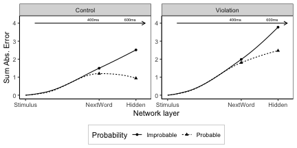

```r
# mapping = aes_string(x="depth", y=dependMeasure, colour = "Probability",linetype="Probability")
      p = drawERP(coulagreeinput,dependMeasure,"Probability",iv4="Agreement", span=1, timeline.y=4,timesize=2,xmax=7)
 #     p = p + facet_wrap(~ Agreement)
      p
```

```r
  if (!noslopes){ # when doing final version, change noslopes to FALSE
    myggsave("img/agreelearn.png",width=figwidth,height=figheight)
  }
```

CUT AND PASTE INTO LATEX DOC click in box and use right arrow to see whole text

```latex
This is an example of the stimuli used in the model.


\begin{tabular}{l|l|l}
\hline
Number & Agreement & Example\\
\hline
Singular2 & Control & the boy take -ss a stick . .\\
\hline
Singular1 & Control & the father -s taste wine -s . .\\
\hline
Singular2 & Violation & the mother push a kite . .\\
\hline
Singular1 & Control & the wife -s take the toy . .\\
\hline
\end{tabular}
The maximal model for the data had random slopes  + (1 + cviolation*cp6layer*cprob - cviolation:cp6layer:cprob |sub)

Mixed Model Results
a main effect of cviolation ,$\beta$=0.97, SE=0.11, $\chi^2$(1)=11.25, p$<$0.001
no main effect of cp6layer ,$\beta$=0.8, SE=0.15, $\chi^2$(1)=0.23, p=0.631
no main effect of cprob ,$\beta$=-0.84, SE=0.14, $\chi^2$(1)=0, p=1.000
an interaction of cviolation:cp6layer ,$\beta$=0.85, SE=0.21, $\chi^2$(1)=21.1, p$<$0.001
no interaction of cviolation:cprob ,$\beta$=0.19, SE=0.24, $\chi^2$(1)=0.1, p=0.752
an interaction of cp6layer:cprob ,$\beta$=-1.2, SE=0.26, $\chi^2$(1)=12.29, p$<$0.001
@@no interaction of cviolation:cp6layer:cprob ,$\beta$=0.15, SE=0.39, $\chi^2$(1)=0.52, p=0.471

Posthoc tests for  layer = word
 @@Posthoc: There was no difference for Improbable - Probable, p=0.0954
Posthoc tests for  layer = hidden
 @@Posthoc: There was a significant difference for Improbable - Probable, diff = 2.4676, t(9)=9.23, p$<$0.001
ratio  Improbable - Probable   7.426  rev  0.135
```

## Rommer Federmeier

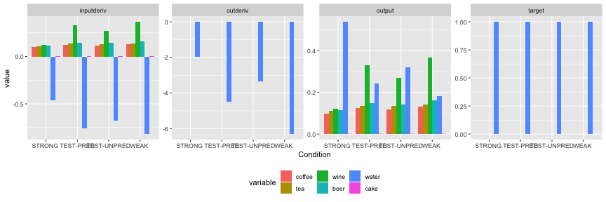

```r
# This is Coulson et al
write("Rommer Federmeier", stderr())
romFinalN = subset(rommerdf, wordcat %in% c('NOUNI'))
showWordOutError("coffee,tea,wine,beer,water,cake",c("Condition","measure"),romFinalN)
```

```r
romFinalN$vrom=NULL
romFinalN$Condition = str_replace(romFinalN$Condition," +","")
romFinalNtest= subset(romFinalN, Condition %in% c("TEST-UNPRED","TEST-PRED"))

print(head(romFinalNtest[romFinalNtest$measure=="target",c("word","wordcat","Condition","Example","tick")])) # check
```

```
##        word wordcat   Condition                          Example tick
## 19657 water   NOUNI   TEST-PRED   he is taste -ing the water . .    6
## 19852 water   NOUNI TEST-UNPRED   he is taste -ing the water . .    6
## 20047 water   NOUNI   TEST-PRED  the uncle taste -ss a water . .    6
## 20242 water   NOUNI TEST-UNPRED  the uncle taste -ss a water . .    6
## 20437 water   NOUNI   TEST-PRED      she taste -ed the water . .    5
## 20632 water   NOUNI TEST-UNPRED      she taste -ed the water . .    5
```

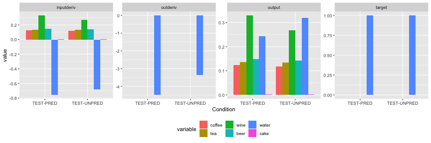

```r
# check that layers are the right size

showWordOutError("coffee,tea,wine,beer,water,cake",c("Condition","measure"),romFinalNtest)
```

```
##   sub devellearn  epoch  word wordcat contfunc
## 1  s0       <NA> 100000 water   NOUNI        C
## 2  s0       <NA> 100000 water   NOUNI        C
## 3  s0       <NA> 100000 water   NOUNI        C
## 4  s0       <NA> 100000 water   NOUNI        C
## 5  s0       <NA> 100000 water   NOUNI        C
## 6  s0       <NA> 100000 water   NOUNI        C
##                           Example Condition tick    layer    measure depth
## 1  he is taste -ing the water . . TEST-PRED    6     word   outderiv     1
## 2  he is taste -ing the water . . TEST-PRED    6     word inputderiv     1
## 3  he is taste -ing the water . . TEST-PRED    6 compress   outderiv     2
## 4  he is taste -ing the water . . TEST-PRED    6 compress inputderiv     2
## 5  he is taste -ing the water . . TEST-PRED    6   hidden   outderiv     3
## 6  he is taste -ing the water . . TEST-PRED    6   hidden inputderiv     3
##   variable      value
## 1   abssum  4.5751810
## 2   abssum  1.5628583
## 3   abssum 10.0684366
## 4   abssum  0.3121806
## 5   abssum  4.4232054
## 6   abssum  0.3329172
```

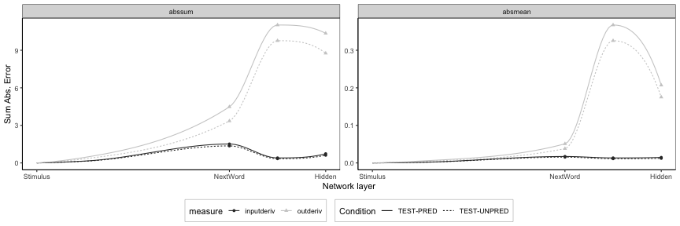

```r
# make erp figure with different measures
#mapping = aes(x=depth, y=value, colour = Condition,linetype=Condition)
romrawpostverbnotargout.df=removeWordsDrawERP(romFinalNtest,"value","Condition","measure","variable",showFig=TRUE)
```

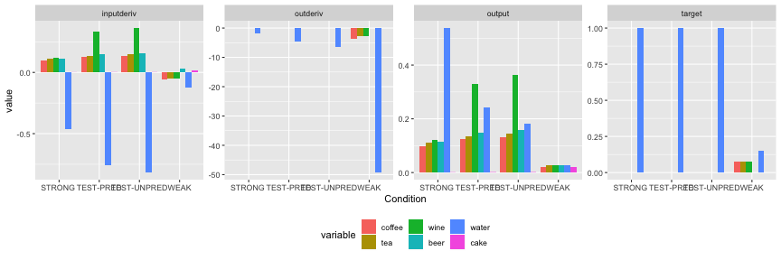

```r
rominput  = subset(romrawpostverbnotargout.df,measure == mainMeasure & layer %in% c("word",p600layer) )
rominput$Prime = factor(rominput$Condition,labels=c("Predictable","Unpredictable"))

romNotFinalN = subset(rommerNotdf, wordcat %in% c('NOUNI'))
showWordOutError("coffee,tea,wine,beer,water,cake",c("Condition","measure"),romNotFinalN)
```

```r
romNotFinalN$vromNot=NULL
romNotFinalN$Condition = str_replace(romNotFinalN$Condition," +","")
romNotFinalNtest= subset(romNotFinalN, Condition %in% c("TEST-UNPRED","TEST-PRED"))

print(head(romNotFinalNtest[romNotFinalNtest$measure=="target",c("word","wordcat","Condition","Example","tick")])) # check
```

```
##        word wordcat   Condition                          Example tick
## 14015 water   NOUNI   TEST-PRED   he is taste -ing the water . .    6
## 14184 water   NOUNI TEST-UNPRED   he is taste -ing the water . .    6
## 14379 water   NOUNI   TEST-PRED  the uncle taste -ss a water . .    6
## 14561 water   NOUNI TEST-UNPRED  the uncle taste -ss a water . .    6
## 14756 water   NOUNI   TEST-PRED      she taste -ed the water . .    5
## 14912 water   NOUNI TEST-UNPRED      she taste -ed the water . .    5
```

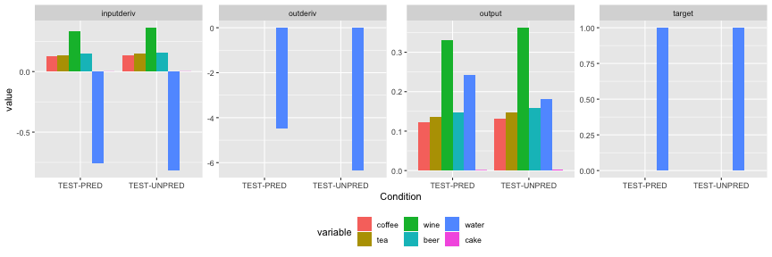

```r
# check that layers are the right size

showWordOutError("coffee,tea,wine,beer,water,cake",c("Condition","measure"),romNotFinalNtest)
```

```
##   sub devellearn  epoch  word wordcat contfunc
## 1  s0       <NA> 100000 water   NOUNI        C
## 2  s0       <NA> 100000 water   NOUNI        C
## 3  s0       <NA> 100000 water   NOUNI        C
## 4  s0       <NA> 100000 water   NOUNI        C
## 5  s0       <NA> 100000 water   NOUNI        C
## 6  s0       <NA> 100000 water   NOUNI        C
##                           Example Condition tick    layer    measure depth
## 1  he is taste -ing the water . . TEST-PRED    6     word   outderiv     1
## 2  he is taste -ing the water . . TEST-PRED    6     word inputderiv     1
## 3  he is taste -ing the water . . TEST-PRED    6 compress   outderiv     2
## 4  he is taste -ing the water . . TEST-PRED    6 compress inputderiv     2
## 5  he is taste -ing the water . . TEST-PRED    6   hidden   outderiv     3
## 6  he is taste -ing the water . . TEST-PRED    6   hidden inputderiv     3
##   variable      value
## 1   abssum  4.5751810
## 2   abssum  1.5628583
## 3   abssum 10.0684366
## 4   abssum  0.3121806
## 5   abssum  4.4232054
## 6   abssum  0.3329172
```

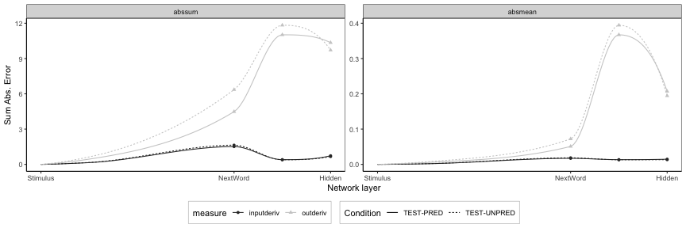

```r
romNotrawpostverbnotargout.df=removeWordsDrawERP(romNotFinalNtest,"value","Condition","measure","variable",showFig=TRUE)
```

```r
interactionText="NO TEXT"
modellist2 = list()

romNotinput  = subset(romNotrawpostverbnotargout.df,measure == mainMeasure & layer %in% c("word",p600layer) )
romNotinput$Prime = factor(romNotinput$Condition,labels=c("Predictable","Unpredictable"))

rominput$exp = "repetition"
romNotinput$exp = "norepetition"
rominput2= rbind(rominput,romNotinput)
aggregate(abssum ~ Condition + exp + layer, rominput2,mean)
```

```
##     Condition          exp  layer    abssum
## 1   TEST-PRED norepetition   word 1.5131503
## 2 TEST-UNPRED norepetition   word 1.6354943
## 3   TEST-PRED   repetition   word 1.5131503
## 4 TEST-UNPRED   repetition   word 1.3608776
## 5   TEST-PRED norepetition hidden 0.7347092
## 6 TEST-UNPRED norepetition hidden 0.6662879
## 7   TEST-PRED   repetition hidden 0.7347092
## 8 TEST-UNPRED   repetition hidden 0.6168264
```

```r
rominput4= subset(rominput2,!(exp == "norepetition" & Condition == "TEST-PRED"))
xtabs(~ Condition + exp, rominput4)
```

```
##              exp
## Condition     norepetition repetition
##   TEST-PRED              0        300
##   TEST-UNPRED          300        300
```

```r
rominput4$Condition2=as.character(rominput4$Condition)
rominput4$Condition2[rominput4$exp == "norepetition"]="Not Previously Seen"
rominput4$Condition2 = factor(rominput4$Condition2,labels=c("Not Previously Seen","Previously Predictable","Previously Unpredictable"))
rominput4$cp6layer = ifelse(rominput4$layer==p600layer,0.5,-0.5)

romexamdf = subset(rommerdf,measure == mainMeasure  & layer == "word" & tick == 1,c(1:12))
exampleTable = romexamdf[c(1,3,4),c("Condition","Example")]
exampleTable$Condition = factor(exampleTable$Condition,labels =c("Predictable Prime","Target","Unpredictable Prime"))
romNotexamdf = subset(rommerNotdf,measure == mainMeasure  & layer == "word" & tick == 1,c(1:12))
exampleTable2 = romNotexamdf[c(1,3,4),c("Condition","Example")]
exampleTable2$Condition = factor(exampleTable$Condition,labels =c("Predictable Prime","Target","Unpredictable Prime"))

exampleTable3 = rbind(exampleTable,exampleTable2)
exampleTable3 = exampleTable3[c(1,2,5,6),]
exampleTable3$Condition = c("Previously Predictable","Previously Unpredictable","Not Previously Seen","Critical Target")
exampleTable3[,c(2,1)]
```

```
##                               Example                Condition
## 19503     she drink -ss the water . .   Previously Predictable
## 19698     she sniff -ss the water . . Previously Unpredictable
## 14056         a grandma will jump . .      Not Previously Seen
## 14121  he is taste -ing the water . .          Critical Target
```

```r
tabletext3 = kable(exampleTable3[,c(2,1)],format="latex",booktab=T,row.names=FALSE)
print(exampleTable3)
```

```
##                      Condition                         Example
## 19503   Previously Predictable     she drink -ss the water . .
## 19698 Previously Unpredictable     she sniff -ss the water . .
## 14056      Not Previously Seen         a grandma will jump . .
## 14121          Critical Target  he is taste -ing the water . .
```

```r
randomeff = paste(" + (1 +layer |sub)")
rominput4$seen =ifelse(rominput4$Condition2=="Not Previously Seen",1,-0.5)
rominput4$pred = 0
rominput4$pred[rominput4$Condition2=="Previously Predictable"]=0.5
rominput4$pred[rominput4$Condition2=="Previously Unpredictable"]=-0.5
contrasts(rominput4$Condition2)<-contr.helmert(3)[c(3,2,1),]

if (noslopes){ randomeff = " + (1 | sub)"}
formu = as.formula(paste(dependMeasure,"~ seen*cp6layer +  pred*cp6layer",randomeff))
omnimodel = lmer(formu, rominput4,control=lmerControl(optimizer = "bobyqa",optCtrl=list(maxfun=50000)))
print(summary(omnimodel))
```

```
## Linear mixed model fit by REML ['lmerMod']
## Formula: abssum ~ seen * cp6layer + pred * cp6layer + (1 + layer | sub)
##    Data: rominput4
## Control: lmerControl(optimizer = "bobyqa", optCtrl = list(maxfun = 50000))
##
## REML criterion at convergence: -469.9
##
## Scaled residuals:
##     Min      1Q  Median      3Q     Max
## -3.8464 -0.4697 -0.0111  0.3998  5.3280
##
## Random effects:
##  Groups   Name        Variance Std.Dev. Corr
##  sub      (Intercept) 0.01534  0.1239
##           layerhidden 0.06867  0.2621   -0.51
##  Residual             0.03099  0.1760
## Number of obs: 900, groups:  sub, 10
##
## Fixed effects:
##                Estimate Std. Error t value
## (Intercept)    1.087891   0.040211  27.055
## seen           0.063000   0.008299   7.592
## cp6layer      -0.830566   0.083695  -9.924
## pred           0.135078   0.014374   9.397
## seen:cp6layer -0.138640   0.016598  -8.353
## cp6layer:pred -0.034390   0.028748  -1.196
##
## Correlation of Fixed Effects:
##             (Intr) seen  cp6lyr pred  sn:cp6
## seen        0.000
## cp6layer    0.525  0.000
## pred        0.000  0.000 0.000
## seen:cp6lyr 0.000  0.000 0.000  0.000
## cp6layr:prd 0.000  0.000 0.000  0.000 0.000
```

```r
modellist2 = modelComparison(omnimodel) # create anova table
```

```
## [1] "remove . ~ . -  cp6layer:pred "
```

```
## refitting model(s) with ML (instead of REML)
```

```
## Data: rominput4
## Models:
## model2: abssum ~ seen + cp6layer + pred + (1 + layer | sub) + seen:cp6layer
## model: abssum ~ seen * cp6layer + pred * cp6layer + (1 + layer | sub)
##        Df     AIC     BIC logLik deviance  Chisq Chi Df Pr(>Chisq)
## model2  9 -484.67 -441.45 251.34  -502.67
## model  10 -484.11 -436.08 252.05  -504.11 1.4364      1     0.2307
## [1] "########## Above comparison for  cp6layer:pred "
## [1] "remove . ~ . -  seen:cp6layer "
```

```
## refitting model(s) with ML (instead of REML)
```

```
## Data: rominput4
## Models:
## model2: abssum ~ seen + cp6layer + pred + (1 + layer | sub)
## model: abssum ~ seen + cp6layer + pred + (1 + layer | sub) + seen:cp6layer
##        Df     AIC     BIC logLik deviance  Chisq Chi Df Pr(>Chisq)
## model2  8 -419.34 -380.92 217.67  -435.34
## model   9 -484.67 -441.45 251.34  -502.67 67.335      1  2.291e-16 ***
## ---
## Signif. codes:  0 '***' 0.001 '**' 0.01 '*' 0.05 '.' 0.1 ' ' 1
## [1] "########## Above comparison for  seen:cp6layer  *** "
## [1] "remove . ~ . -  pred "
```

```
## refitting model(s) with ML (instead of REML)
```

```
## Data: rominput4
## Models:
## model2: abssum ~ seen + cp6layer + (1 + layer | sub)
## model: abssum ~ seen + cp6layer + pred + (1 + layer | sub)
##        Df     AIC     BIC logLik deviance  Chisq Chi Df Pr(>Chisq)
## model2  7 -342.89 -309.28 178.45  -356.89
## model   8 -419.34 -380.92 217.67  -435.34 78.444      1  < 2.2e-16 ***
## ---
## Signif. codes:  0 '***' 0.001 '**' 0.01 '*' 0.05 '.' 0.1 ' ' 1
## [1] "########## Above comparison for  pred  *** "
## [1] "remove . ~ . -  cp6layer "
```

```
## refitting model(s) with ML (instead of REML)
```

```
## Data: rominput4
## Models:
## model2: abssum ~ seen + (1 + layer | sub)
## model: abssum ~ seen + cp6layer + (1 + layer | sub)
##        Df     AIC     BIC logLik deviance  Chisq Chi Df Pr(>Chisq)
## model2  6 -320.09 -291.28 166.05  -332.09
## model   7 -342.89 -309.28 178.45  -356.89 24.801      1  6.357e-07 ***
## ---
## Signif. codes:  0 '***' 0.001 '**' 0.01 '*' 0.05 '.' 0.1 ' ' 1
## [1] "########## Above comparison for  cp6layer  *** "
## [1] "remove . ~ . -  seen "
```

```
## refitting model(s) with ML (instead of REML)
```

```
## Data: rominput4
## Models:
## model2: abssum ~ (1 + layer | sub)
## model: abssum ~ seen + (1 + layer | sub)
##        Df     AIC     BIC logLik deviance  Chisq Chi Df Pr(>Chisq)
## model2  5 -274.43 -250.42 142.22  -284.43
## model   6 -320.09 -291.28 166.05  -332.09 47.662      1  5.065e-12 ***
## ---
## Signif. codes:  0 '***' 0.001 '**' 0.01 '*' 0.05 '.' 0.1 ' ' 1
## [1] "########## Above comparison for  seen  *** "
```

```r
  # this model is for posthocs

rominput4word = subset(rominput4,layer=="word")
randomeff2 = paste(" + (1  |sub)")
formu = as.formula(paste(dependMeasure,"~ pred + seen",randomeff2))
omnimodelw = lmer(formu, rominput4word ,control=lmerControl(optimizer = "bobyqa",optCtrl=list(maxfun=50000)))
print(summary(omnimodelw))
```

```
## Linear mixed model fit by REML ['lmerMod']
## Formula: abssum ~ pred + seen + (1 | sub)
##    Data: rominput4word
## Control: lmerControl(optimizer = "bobyqa", optCtrl = list(maxfun = 50000))
##
## REML criterion at convergence: -854.3
##
## Scaled residuals:
##     Min      1Q  Median      3Q     Max
## -4.7482 -0.4860  0.0008  0.5856  2.8554
##
## Random effects:
##  Groups   Name        Variance Std.Dev.
##  sub      (Intercept) 0.015860 0.12594
##  Residual             0.007627 0.08733
## Number of obs: 450, groups:  sub, 10
##
## Fixed effects:
##             Estimate Std. Error t value
## (Intercept) 1.503174   0.040037   37.55
## pred        0.152273   0.010084   15.10
## seen        0.132320   0.005822   22.73
##
## Correlation of Fixed Effects:
##      (Intr) pred
## pred 0.000
## seen 0.000  0.000
```

```r
modellist3w = modelComparison(omnimodelw) # create anova table
```

```
## [1] "remove . ~ . -  seen "
```

```
## refitting model(s) with ML (instead of REML)
```

```
## Data: rominput4word
## Models:
## model2: abssum ~ pred + (1 | sub)
## model: abssum ~ pred + seen + (1 | sub)
##        Df     AIC     BIC logLik deviance  Chisq Chi Df Pr(>Chisq)
## model2  4 -523.99 -507.55 266.00  -531.99
## model   5 -864.74 -844.19 437.37  -874.74 342.75      1  < 2.2e-16 ***
## ---
## Signif. codes:  0 '***' 0.001 '**' 0.01 '*' 0.05 '.' 0.1 ' ' 1
## [1] "########## Above comparison for  seen  *** "
## [1] "remove . ~ . -  pred "
```

```
## refitting model(s) with ML (instead of REML)
```

```
## Data: rominput4word
## Models:
## model2: abssum ~ (1 | sub)
## model: abssum ~ pred + (1 | sub)
##        Df     AIC     BIC logLik deviance  Chisq Chi Df Pr(>Chisq)
## model2  3 -431.74 -419.41 218.87  -437.74
## model   4 -523.99 -507.55 266.00  -531.99 94.249      1  < 2.2e-16 ***
## ---
## Signif. codes:  0 '***' 0.001 '**' 0.01 '*' 0.05 '.' 0.1 ' ' 1
## [1] "########## Above comparison for  pred  *** "
```

```r
rominput4hid = subset(rominput4,layer=="hidden")
omnimodelh = lmer(formu, rominput4hid,control=lmerControl(optimizer = "bobyqa",optCtrl=list(maxfun=50000)))
print(summary(omnimodelh))
```

```
## Linear mixed model fit by REML ['lmerMod']
## Formula: abssum ~ pred + seen + (1 | sub)
##    Data: rominput4hid
## Control: lmerControl(optimizer = "bobyqa", optCtrl = list(maxfun = 50000))
##
## REML criterion at convergence: 16.4
##
## Scaled residuals:
##     Min      1Q  Median      3Q     Max
## -2.8909 -0.6411 -0.0735  0.5026  4.0139
##
## Random effects:
##  Groups   Name        Variance Std.Dev.
##  sub      (Intercept) 0.05013  0.2239
##  Residual             0.05436  0.2331
## Number of obs: 450, groups:  sub, 10
##
## Fixed effects:
##             Estimate Std. Error t value
## (Intercept)  0.67261    0.07165   9.388
## pred         0.11788    0.02692   4.379
## seen        -0.00632    0.01554  -0.407
##
## Correlation of Fixed Effects:
##      (Intr) pred
## pred 0.000
## seen 0.000  0.000
```

```r
modellist3h = modelComparison(omnimodelh) # create anova table
```

```
## [1] "remove . ~ . -  seen "
```

```
## refitting model(s) with ML (instead of REML)
```

```
## Data: rominput4hid
## Models:
## model2: abssum ~ pred + (1 | sub)
## model: abssum ~ pred + seen + (1 | sub)
##        Df     AIC    BIC   logLik deviance  Chisq Chi Df Pr(>Chisq)
## model2  4  9.1517 25.589 -0.57584  1.15167
## model   5 10.9856 31.532 -0.49281  0.98561 0.1661      1     0.6836
## [1] "########## Above comparison for  seen "
## [1] "remove . ~ . -  pred "
```

```
## refitting model(s) with ML (instead of REML)
```

```
## Data: rominput4hid
## Models:
## model2: abssum ~ (1 | sub)
## model: abssum ~ pred + (1 | sub)
##        Df     AIC    BIC  logLik deviance  Chisq Chi Df Pr(>Chisq)
## model2  3 25.9969 38.325 -9.9984  19.9969
## model   4  9.1517 25.589 -0.5758   1.1517 18.845      1  1.418e-05 ***
## ---
## Signif. codes:  0 '***' 0.001 '**' 0.01 '*' 0.05 '.' 0.1 ' ' 1
## [1] "########## Above comparison for  pred  *** "
```

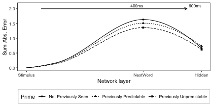

```r
rominput4$Prime = rominput4$Condition2
  p = drawERP(rominput4,dependMeasure, "Prime", span=1, timeline.y=2)
  p
```

```r
if (!noslopes){ # when doing final version, change noslopes to FALSE
    myggsave("img/rommers2.png",width=figwidth,height=figheight)
}
```

CUT AND PASTE INTO LATEX DOC click in box and use right arrow to see whole text

```latex
This is an example of the stimuli used in the model.


\begin{tabular}{ll}
\toprule
Example & Condition\\
\midrule
she drink -ss the water . . & Previously Predictable\\
she sniff -ss the water . . & Previously Unpredictable\\
a grandma will jump . . & Not Previously Seen\\
he is taste -ing the water . . & Critical Target\\
\bottomrule
\end{tabular}
The maximal model for the data had random slopes  + (1 +layer |sub)

Mixed Model Results
a main effect of seen ,$\beta$=0.063, SE=0.0083, $\chi^2$(1)=47.66, p$<$0.001
a main effect of cp6layer ,$\beta$=-0.83, SE=0.084, $\chi^2$(1)=24.8, p$<$0.001
a main effect of pred ,$\beta$=0.14, SE=0.014, $\chi^2$(1)=78.44, p$<$0.001
an interaction of seen:cp6layer ,$\beta$=-0.14, SE=0.017, $\chi^2$(1)=67.33, p$<$0.001
@@no interaction of cp6layer:pred ,$\beta$=-0.034, SE=0.029, $\chi^2$(1)=1.44, p=0.231

Mixed Model Results
a main effect of pred ,$\beta$=0.15, SE=0.01, $\chi^2$(1)=94.25, p$<$0.001
@@a main effect of seen ,$\beta$=0.13, SE=0.0058, $\chi^2$(1)=342.75, p$<$0.001

Mixed Model Results
a main effect of pred ,$\beta$=0.12, SE=0.027, $\chi^2$(1)=18.85, p$<$0.001
@@no main effect of seen ,$\beta$=-0.0063, SE=0.016, $\chi^2$(1)=0.17, p=0.684
```

## Overall accuracy results

```r
test = read.csv("testdata.csv")
```

[output not shown]

```r
testsum = aggregate(cbind(corr,total) ~ epoch, test, sum)
```

```
## Error in terms.formula(formula, data = data): 'data' argument is of the wrong type
```

```r
testsum=rbind(testsum,data.frame(epoch=0,corr=0,total=200))
```

```
## Error in rbind(testsum, data.frame(epoch = 0, corr = 0, total = 200)): object 'testsum' not found
```

```r
testsum$perc = 100* testsum$corr/testsum$total
```

```
## Error in eval(expr, envir, enclos): object 'testsum' not found
```

```r
p1=ggplot(testsum,aes(x=epoch,y=perc))+geom_line()+ylim(0,100)
```

```
## Error in ggplot(testsum, aes(x = epoch, y = perc)): object 'testsum' not found
```

[figure not shown]

```r
  p1 = p1 + scale_colour_brewer( palette="Set1")
  p1 = p1 + theme_bw() + xlab("Number of patterns trained")
p1
```

```r
paste("@@Test Accuracy ",tail(aggregate(perc ~ epoch, test, mean),1))
```

```
## Error in terms.formula(formula, data = data): 'data' argument is of the wrong type
```

## Example data for introduction

- These figures below are made up data that help to explain the model
- Word Level: The children went out to …

```
##         cond Context value       variable Lexical
## 1   Expected  Strong   0.7 Sum Abs. Error    move
## 2 Unexpected  Strong   1.5 Sum Abs. Error    move
## 3   Expected    Weak   1.1 Sum Abs. Error    move
## 4 Unexpected    Weak   1.5 Sum Abs. Error    move
```

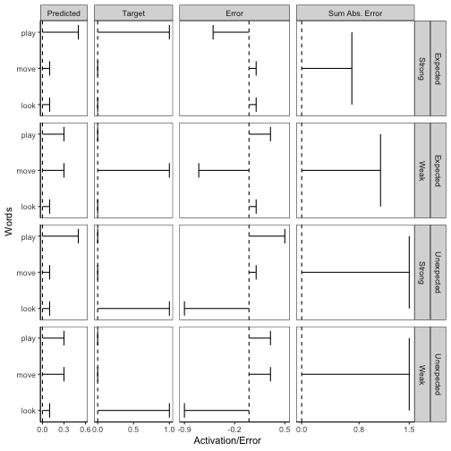

- N400 is sensitive to cloze probabilites of words

## Agreement Lexical Level: The spoilt child throws the toys on the floor

```
##   Grammaticality value       variable Lexical
## 1          Gram.   1.2 Sum Abs. Error     SUM
## 2        Ungram.   1.6 Sum Abs. Error     SUM
```

```
##    Grammaticality Lexical  variable value
## 1           Gram.     the Predicted   0.3
## 2           Gram.       a Predicted   0.3
## 3           Gram.     -ed Predicted   0.1
## 4           Gram.     -ss Predicted   0.1
## 5         Ungram.     the Predicted   0.3
## 6         Ungram.       a Predicted   0.3
## 7         Ungram.     -ed Predicted   0.1
## 8         Ungram.     -ss Predicted   0.1
## 9           Gram.     the    Target   1.0
## 10          Gram.       a    Target   0.0
## 11          Gram.     -ed    Target   0.0
## 12          Gram.     -ss    Target   0.0
## 13        Ungram.     the    Target   0.0
## 14        Ungram.       a    Target   0.0
## 15        Ungram.     -ed    Target   1.0
## 16        Ungram.     -ss    Target   0.0
## 17          Gram.     the     Error  -0.7
## 18          Gram.       a     Error   0.3
## 19          Gram.     -ed     Error   0.1
## 20          Gram.     -ss     Error   0.1
## 21        Ungram.     the     Error   0.3
## 22        Ungram.       a     Error   0.3
## 23        Ungram.     -ed     Error  -0.9
## 24        Ungram.     -ss     Error   0.1
```

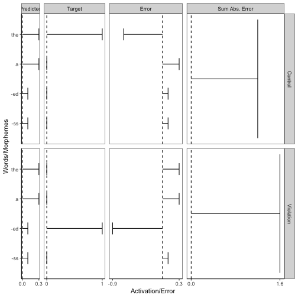

- Syntactic distinctions do not show an N400

## Agreement Syntactic Level: The spoilt child throws the toys on the floor

```
##   Grammaticality Lexical Predicted Target Error absError Weight
## 1          Gram.     the       0.3      1  -0.7      0.7      4
## 2          Gram.       a       0.3      0   0.3      0.3      4
## 3          Gram.     -ed       0.1      0   0.1      0.1     -1
## 4          Gram.     -ss       0.1      0   0.1      0.1     -1
## 5        Ungram.     the       0.3      0   0.3      0.3      4
## 6        Ungram.       a       0.3      0   0.3      0.3      4
## 7        Ungram.     -ed       0.1      1  -0.9      0.9     -1
## 8        Ungram.     -ss       0.1      0   0.1      0.1     -1
##   NetinputBack Weight2 NetinputBack2
## 1         -2.8      -1           0.7
## 2          1.2      -1          -0.3
## 3         -0.1       4           0.4
## 4         -0.1       4           0.4
## 5          1.2      -1          -0.3
## 6          1.2      -1          -0.3
## 7          0.9       4          -3.6
## 8         -0.1       4           0.4
```

```
##   Grammaticality NetinputBack NetinputBack2 Error
## 1          Gram.         -1.8           1.2     3
## 2        Ungram.          3.2          -3.8     7
```

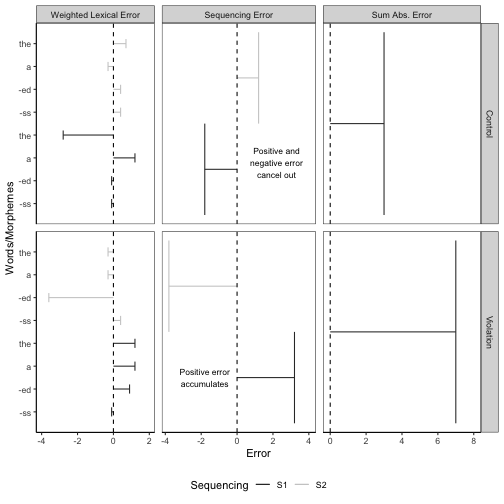

## Agreement Wave ERP: The spoilt child throws the toys on the floor

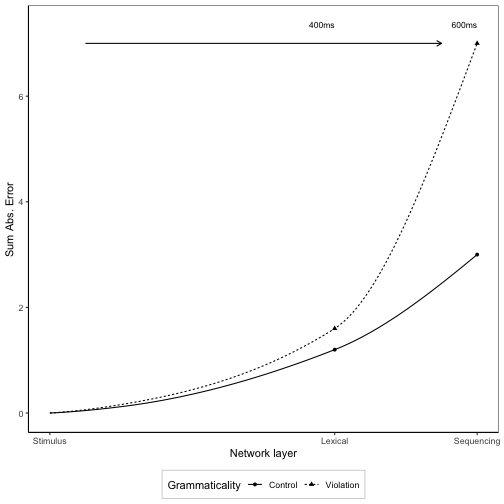

## Draw Sequencing-Hidden Network

```
##   Grammaticality Lexical Predicted Target Error absError Weight
## 1          Gram.     the       0.3      1  -0.7      0.7      4
## 2          Gram.       a       0.3      0   0.3      0.3      4
## 3          Gram.     -ed       0.1      0   0.1      0.1     -1
## 4          Gram.     -ss       0.1      0   0.1      0.1     -1
## 5        Ungram.     the       0.3      0   0.3      0.3      4
## 6        Ungram.       a       0.3      0   0.3      0.3      4
## 7        Ungram.     -ed       0.1      1  -0.9      0.9     -1
## 8        Ungram.     -ss       0.1      0   0.1      0.1     -1
##   NetinputBack Weight2 NetinputBack2 Sequencing
## 1         -2.8      -1           0.7         S1
## 2          1.2      -1          -0.3         S1
## 3         -0.1       4           0.4         S1
## 4         -0.1       4           0.4         S1
## 5          1.2      -1          -0.3         S1
## 6          1.2      -1          -0.3         S1
## 7          0.9       4          -3.6         S1
## 8         -0.1       4           0.4         S1
```

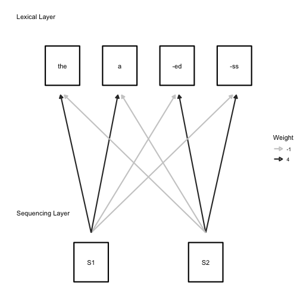

## Word Level

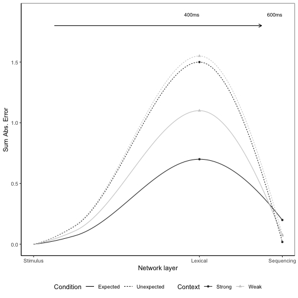

## Draw Network

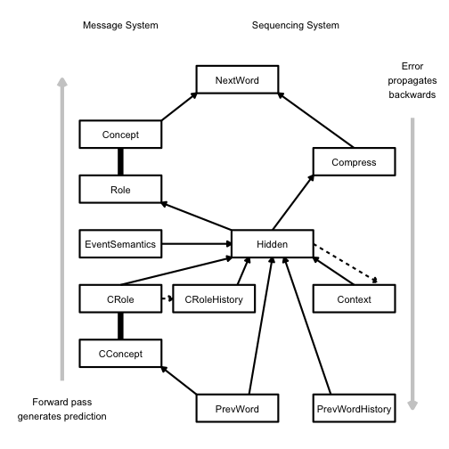

## Draw Brain1

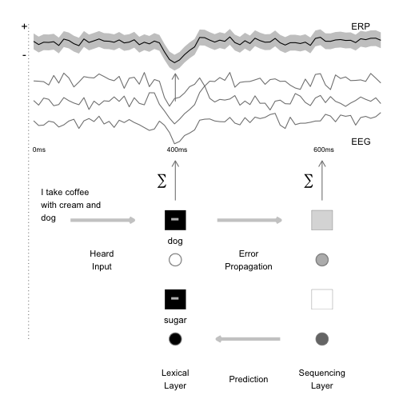

## Draw Brain2

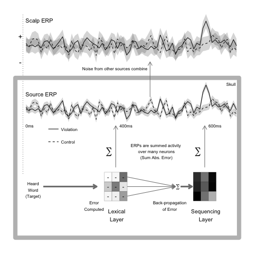

## Draw Brain3

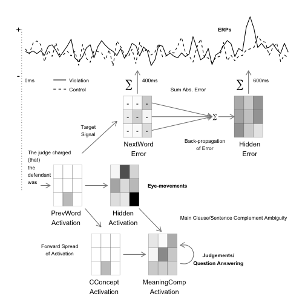